# R Notebook for conducting Minimum Detectable Change (MDC) Analysis to design a monitoring strategy for the Upper Yaquina River TMDL Implementation Plan

# Set up R session

There are conflicts among some of the tidyverse package and other packages. To resolve this I used the “conflicted” package to say which package I prefer for conflicted functions.

```r
library(conflicted)
conflict_prefer("filter", "dplyr")
```

```
[conflicted] Will prefer dplyr::filter over any other package.
```

```r
conflict_prefer("lag", "dplyr")
```

```
[conflicted] Will prefer dplyr::lag over any other package.
```

# Load packages used in notebook

```r
result_tv <- library(tidyverse)
result_ggp <- library(ggplot2)
results_mts <- library(moments)
results_ptw <- library(patchwork)
results_bt <- library(boot)
results_br <- library(broom)
results_sc <- library(scales)
```

# Bacteria Data

Read bacteria data from “CSV” file

```r
df <- read.csv("UpperYaquinaBacteria.csv")
```

Check the classes of the columns in the data frame

```r
str(df)
```

```
'data.frame':   396 obs. of  3 variables:
 $ STATION: int  11476 11476 11476 11476 11476 11476 11476 11476 11476 11476 ...
 $ date   : chr  "1993-09-21" "1996-06-18" "1996-06-18" "1996-06-18" ...
 $ EC_val : int  14 80 80 80 49 79 23 46 33 33 ...
```

Make “STATION” column a character class for use as a category

```r
df$STATION <- as.character(df$STATION)
```

The “date” column is currently a character type and we need a date/time type.

```r
df$date <- as.Date(df$date, format = "%Y-%m-%d")
```

Check the classes again

```r
str(df)
```

```
'data.frame':   396 obs. of  3 variables:
 $ STATION: chr  "11476" "11476" "11476" "11476" ...
 $ date   : Date, format: "1993-09-21" "1996-06-18" "1996-06-18" "1996-06-18" ...
 $ EC_val : int  14 80 80 80 49 79 23 46 33 33 ...
```

# Explore Data

The log10 transformation is essential in analyzing bacteria count data, which often has a wide range and right-skewed distribution. This transformation normalizes the data, making it suitable for statistical methods that assume normality. It also stabilizes the variance, addressing the issue of heteroscedasticity. By compressing the range of values, it makes the data more manageable for analysis. This is particularly relevant as bacterial growth is exponential, and log scales can reflect underlying biological processes more accurately.

I used I used box-plots first to visually assess the distribution of the data by station

```r
boxplot_org <- ggplot(df, aes(x = STATION, y = EC_val, fill = STATION)) +
  geom_boxplot() +
  labs(title = "Boxplot by Station",
       x = "Station",
       y = "E. Coli Concentration (cfu/100 ml)") +
  scale_fill_brewer(palette = "Pastel1") +  # Change color palette
  theme_minimal()  # Use a minimal theme +
  coord_fixed(ratio = 1)  # Preserve aspect ratio
```

[output not shown]

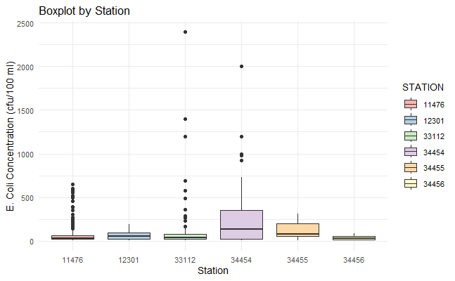

```r
plot(boxplot_org)
```

Apply the log10 transformation of the E. coli values and plot as boxplots (Make Y-axis log using semi-log settings)

```r
boxplot_log10 <- ggplot(df, aes(x = STATION, y = EC_val, fill = STATION)) +
  geom_boxplot() +
  scale_y_log10() +
  labs(title = "Boxplot by Station",
       x = "Station",
       y = "Log10 of E. Coli Concentration (cfu/100 ml)") +
  scale_fill_brewer(palette = "Pastel1") +  # Change color palette
  theme_minimal()  # Use a minimal theme +
  coord_fixed(ratio = 1)  # Preserve aspect ratio
```

[output not shown]